# Workshop d’analyse du Métabolisme Social

UC6 - Economie Ecologique

Simon Jean

simon.jean@agroparistech.fr

AgroParisTech - CIRED - PSAE

## A. Objectifs de l’Atelier

- Comprendre les principes de reproducibilité de l’analyse
- Accéder et préparer les données Eurostat sur les flux de matières
- Calculer les indicateurs métaboliques clés
- Visualiser et comparer les profils métaboliques
- Analyser les tendances et les schémas

Allez sur la page du projet : `https://github.com/sim-jean/intro_mfa`

## B. Workflow et données

### 1. Projets sur R

- Ils permettent de :
  - Regrouper tout le code au sein d’une architecture reproductible i.e. claire & commune
  - Créer des environnements afin d’avoir un code *reproductible*, gérant les dépendances entre projets et dans le temps
  - Partager rapidement et facilement le code entre différents utilisateurs
  - Suivre dans le temps via le contrôle de version, notamment en utilisant Git (ce sera pour une autre fois)

### 2. Reproducibilité

- On parle de reproducibilité à plusieurs niveaux dans l’analyse scientifique :
  - Reproducibilité computationelle : pouvoir répliquer exactement les résultats
  - Reproducibilité empirique : refaire les tests d’une autre manière
  - Reproducibilité conceptuelle : retrouver les mêmes résultats avec de nouvelles données
- Celle ci est en crise : beaucoup de résultats en science ne sont pas réplicables
- Pas simplement la recherche académique, toute production visant à être étayée et partagée doit viser la reproducibilité

### 3. Comment rendre la recherche reproductible?

1. Une architecture claire et organisée par projets:
   - Des fichiers séparés pour les données brutes, traitées et les scripts
2. Contrôle de version : on ne verra pas ça ensemble
3. Management des dépendances :
   - Créer des environnements pour vérouiller les bibliothèques
   - Documenter toutes les dépendances
   - Partager les fichiers `.lock` avec les collaborateurs
4. Pipeline de données :
   - Ne jamais modifier les fichiers de données brutes
   - Créer des scripts séparés pour le nettoyage et l’analyse
   - Construire des fonctions modulaires et réutilisables - c’est un art
   - Documenter la transformation des données
5. Documentation :
   - Maintenez des `README` clairs et exhaustifs
   - Commentez le code
   - Générez des rapports automatisés avec les fichiers `markdown` (`.md`, `.rmd` ou `.qmd` - quarto markdown)
6. Automatisation :
   - Utilisez des chemins relatifs : le package `here()`
   - Créez des rapports reproductibles

### 4. Architecture

Le but est d’avoir une architecture claire, pour que vos résultats puissent être reproduits, avec :

- Les scripts : c’est le texte, le code qui sera exécuté
- Les données : brutes ou nettoyées, ou additionelles de sources extérieures
- Les résultats: figures, tableaux etc
- La documentation : les rapports, ou encore un fichier qui s’appelle le `Readme.md`, qui détaille le projet, les instructions d’utilisation etc.
- Pour commencer, vous allez aller sur la page Github du cours ! `https://github.com/sim-jean/intro_mfa`
- Lisez le fichier `README.md`
- Téléchargez le fichier `.zip` du projet et décompressez le
- Ouvrez le fichier `.proj`
- Puis ouvrez le fichier `script > 01_utilities.qmd` et suivez les instructions relatives à l’environnement et à l’architecture
- On veut créer l’architecture suivante

```
Projet/
├── R/                   # Contient tous les scripts R du projet
│   ├── 01_utilities.rmd # Script d'importation des données
│   ├── 02_cleaning.rmd    # Script de nettoyage des données
│   ├── 03_analysis.rmd    # Script d'analyse des données
│   └── 04_visualisation.rmd # Script pour les graphiques et visualisations
├── data/                # Contient les fichiers de données brutes et traitées
│   ├── raw/             # Données brutes
│   │   └── data1.csv    # Exemple de fichier de données brutes
│   │   └── README.txt   # Texte explicatif des données
│   ├── processed/       # Données nettoyées et traitées
│   │   └── data_clean.csv
│   └── external/        # Données externes ou partagées (ex. bases de données publiques)
│       └── source.csv
├── results/             # Résultats des analyses (sorties, graphiques, tableaux)
│   ├── figures/         # Graphiques générés (png, pdf, etc.)
│   │   └── plot1.png
│   └── tables/          # Tables générées (ex. CSV ou LaTeX)
│       └── table1.csv
├── docs/                 # Documentation du projet (rapports, instructions, etc.)
│   ├── report.pdf       # Rapport principal du projet
│   └── README.md        # Explication du projet, instructions d'utilisation
├── .gitignore           # Fichier pour ignorer certains fichiers dans un dépôt Git (si applicable)
├── renv.lock            # Fichier verrouillant les versions des packages (géré par renv)
├── renv/                # Dossier contenant l'environnement isolé géré par renv
└── README.md            # Fichier d'accueil du projet pour décrire brièvement de quoi il s'agit
```

On utilise le code suivant :

```r
if(!dir.exists(here("data"))){ # Vérifie si le chemin existe déja
  dir.create(here("data"))
  dir.create(here("data", "raw")) # Crée des dossiers à l'intérieur de \data
  dir.create(here("data", "processed"))
  dir.create(here("data", "external"))

  dir.create(here("results"))
  dir.create(here("results", "figure"))
  dir.create(here("results", "tables"))

  dir.create(here("docs"))
}

print("Architecture à jour")
```

```
[1] "Architecture à jour"
```

### 5. Environnement

- Clé pour rendre le travail reproductible :
  - Les versions des packages sont stockées
  - Quand l’environnement est partagé, tout le monde travail avec les mêmes packages, permettant la reproducibilité entre personnes et dans le temps
- Chaque projet peut avoir des versions de package différentes sans encombre

### 6. Packages et environnements

Ensuite, on va télécharger et installer des packages utiles :

- Le package `rmarkdown` et `knitr` pour effectivement avoir des documents en markdown qui soient pris en compte par R
- La collection de package `tidyverse` qui contient entre autres :
  - `tidyr` et `dplyr` : sont essentiels pour la manipulation de données de base ainsi que le recodage, la création de nouvelles variables, le filtrage etc
  - `gpplot2` et `ggsci`: le package de référence pour la data visualisation et des `themes()` (styles) de référence dans la littérature scientifique
- `readxl` : pour lire des données en format `.xlsx`
- `magrittr`: un package qui permet d’utiliser l’opérateur pipe `%>%`, qui permet de connecter les opérations entre elles, simplifiant le processus de $g(h(x))$ à `x %>% h() %>% g()`
- `eurostat` : pour accéder directement aux données d’Eurostat
- `countrycode`: pas sur d’en avoir besoin mais permet d’avoir les bons noms de pays
- `here`: permet d’utiliser des chemins relatifs plutôt qu’absolus (i.e. `~/scripts/utilities.qmd` plutôt que `C:/Users/jean/OneDrive/Desktop/Teaching/AgroParisTech/intro_mfa/scripts/01_utilities.qmd`)

## C. Acquisition des données

- On utilise maintenant le script `02_analysis.qmd`
- On accède à Eurostat grâce au package `eurostat`
  - Trouvez le code du jeu de données pour les données MFA et les données de PIB sur le site web
  - Complétez le code en dessous

```r
# Téléchargement des données de Comptabilité de Flux de Matières

if(!(file.exists(here("data","external", "mfa_data.csv")))){
  # Si les données ne sont pas sauvegardées, on les
  # acquiert et les sauvegarde

  mfa_data <- get_eurostat("env_ac_mfa",  # Utilise la fonction get_eurostat qui nécessite le code du jeu de donnée
                         time_format = "num")

  mfa_data_labeled = label_eurostat(mfa_data) # Récupère les labels de variables


  write.csv(mfa_data_labeled, # Sauvegargde les données localement
            here('data', 'external', 'mfa_data.csv'),
            row.names = F)
}else{
  # Sinon, les données sont lues
  mfa_data_labeled = read.csv(here('data', 'external', 'mfa_data.csv'))
}

# Même mécanisme pour les données de PIB

if(!(file.exists(here("data","external", "gdp_data_filtered.csv")))){
  gdp_data <- get_eurostat("nama_10_gdp",
                        time_format = "num")

  gdp_data_filtered = gdp_data %>%
    filter(na_item == "B1GQ" &
           unit == "CP_MEUR")

  gdp_data_labeled = label_eurostat(gdp_data_filtered)
  gdp_data_full_labeled = label_eurostat(gdp_data)

  write.csv(gdp_data_labeled,
            here('data', 'external', 'gdp_data_filtered.csv'),
            row.names = F)
  write.csv(gdp_data_full_labeled,
            here('data', 'external', 'gdp_data_full_labeled.csv'),
            row.names = F)

}else{
  gdp_data_labeled = read.csv(here('data', 'external', 'gdp_data_filtered.csv'))
  gdp_data_full_labeled = read.csv(here('data', 'external', 'gdp_data_full_labeled.csv'))

}
```

- Biomass
- Metals
- Non-metallic minerals
- Fossil energy carriers
- Other products

```
Table: Catégorie : Biomass

|Material                                                                                                        |
|:---------------------------------------------------------------------------------------------------------------|
|Biomass                                                                                                         |
|Crops (excluding fodder crops)                                                                                  |
|Cereals                                                                                                         |
|Roots, tubers                                                                                                   |
|Sugar crops                                                                                                     |
|Pulses                                                                                                          |
|Nuts                                                                                                            |
|Oil-bearing crops                                                                                               |
|Vegetables                                                                                                      |
|Fruits                                                                                                          |
|Fibres                                                                                                          |
|Other crops (excluding fodder crops) n.e.c.                                                                     |
|Crop residues (used), fodder crops and grazed biomass                                                           |
|Crop residues (used)                                                                                            |
|Straw                                                                                                           |
|Other crop residues (sugar and fodder beet leaves, etc.)                                                        |
|Fodder crops and grazed biomass                                                                                 |
|Fodder crops (including biomass harvest from grassland)                                                         |
|Grazed biomass                                                                                                  |
|Wood                                                                                                            |
|Timber (industrial roundwood)                                                                                   |
|Wood fuel and other extraction                                                                                  |
|Wild fish catch, aquatic plants and animals, hunting and gathering                                              |
|Wild fish catch                                                                                                 |
|All other aquatic animals and plants                                                                            |
|Hunting and gathering                                                                                           |
|Live animals and animal products (excluding wild fish, aquatic plants and animals, hunted and gathered animals) |
|Live animals (excluding wild fish, aquatic plants and animals, hunted and gathered animals)                     |
|Meat and meat preparations                                                                                      |
|Dairy products, birds' eggs, and honey                                                                          |
|Other products from animals (animal fibres, skins, furs, leather, etc.)                                         |
|Products mainly from biomass                                                                                    |
```

```
Table: Catégorie : Metals

|Material                                         |
|:------------------------------------------------|
|Metal ores (gross ores)                          |
|Iron                                             |
|Non-ferrous metal                                |
|Copper                                           |
|Nickel                                           |
|Lead                                             |
|Zinc                                             |
|Tin                                              |
|Gold, silver, platinum and other precious metals |
|Bauxite and other aluminium                      |
|Uranium and thorium                              |
|Other non-ferrous metals                         |
|Products mainly from metals                      |
```

```
Table: Catégorie : Non-metallic minerals

|Material                                                                                           |
|:--------------------------------------------------------------------------------------------------|
|Non-metallic minerals                                                                              |
|Marble, granite, sandstone, porphyry, basalt, other ornamental or building stone (excluding slate) |
|Chalk and dolomite                                                                                 |
|Slate                                                                                              |
|Chemical and fertiliser minerals                                                                   |
|Salt                                                                                               |
|Limestone and gypsum                                                                               |
|Clays and kaolin                                                                                   |
|Sand and gravel                                                                                    |
|Other non-metallic minerals n.e.c.                                                                 |
|Products mainly from non metallic minerals                                                         |
```

```
Table: Catégorie : Fossil energy carriers

|Material                                                                                          |
|:-------------------------------------------------------------------------------------------------|
|Fossil energy materials/carriers                                                                  |
|Coal and other solid energy materials/carriers                                                    |
|Lignite (brown coal)                                                                              |
|Hard coal                                                                                         |
|Oil shale and tar sands                                                                           |
|Peat                                                                                              |
|Liquid and gaseous energy materials/carriers                                                      |
|Crude oil, condensate and natural gas liquids (NGL)                                               |
|Natural gas                                                                                       |
|Fuels bunkered (imports: by resident units abroad); (exports: by non-resident units domestically) |
|Fuel for land transport                                                                           |
|Fuel for water transport                                                                          |
|Fuel for air transport                                                                            |
|Products mainly from fossil energy products                                                       |
```

```
Table: Catégorie : Other products

|Material                                        |
|:-----------------------------------------------|
|Other products                                  |
|Waste for final treatment and disposal          |
|Stage of manufacturing - finished products      |
|Stage of manufacturing - raw products           |
|Stage of manufacturing - semi-finished products |
```

## D. Visualisation des indicateurs par pays

1. Répartissez vous en groupe de deux
2. Ecrivez une fonction pour représenter les indicateurs clés de l’analyse MFA: Domestic extraction, Direct material inputs, domestic consumption, imports and exports
3. Choisissez un pays dans l’UE et sortez son profil métabollique dans les dernières années
- Code
- DE

```r
summary_classes = c('Biomass', 'Metal ores (gross ores)', 'Non-metallic minerals',
                    'Fossil energy materials/carriers', 'Other products')
# Classes qui résument les données, qui sont plus riches

# Faites :
# unique(mfa_data_labeled$material)
# Pour voir l'intégralité des flux

visualizer = function(country, variable, data_ = mfa_data_labeled){
#' Visualizer Function for MFA Indicators
#'
#' Cette fonction génère un graphique ggplot représentant l'évolution temporelle
#' d'un indicateur clé du MFA pour un pays donné.
#'
#' @param country Caractère. Le code du pays à analyser (ex : "France").
#' @param variable Caractère. L'indicateur environnemental à visualiser
#'   (ex : "Domestic extraction", "Direct material inputs", etc.).
#' @param data_ Data frame. Jeu de données contenant les informations MFA.
#'   Par défaut, il s'agit de `mfa_data_labeled`.
#'
#' @return Un objet ggplot représentant le graphique de l'indicateur sélectionné.
#'
#' @examples
#' visualizer("France", "Domestic extraction")

  p = data_%>%
    subset(geo == country)%>%              # On choisit les pays
    subset(unit == "Tonnes per capita")%>% # On garde les tonnes par tête
    subset(indic_env == variable)%>%       # Choisit la variable
    subset(material %in% summary_classes)%>% # Récupère les données agrégées
    ggplot(aes(x=TIME_PERIOD, y=values, fill = material, color = material))+
    geom_area()+ # Fait un plot stacked
    scale_fill_manual(values = palette_mfa)+
    scale_color_manual(values = palette_mfa)+
    custom_theme()+
    ylab('t/cap/yr')+
    xlab('Year')+
    labs(color=NULL,
         fill = NULL)+
    ggtitle(paste(country, ' - ', variable))

  return(p)
}
```

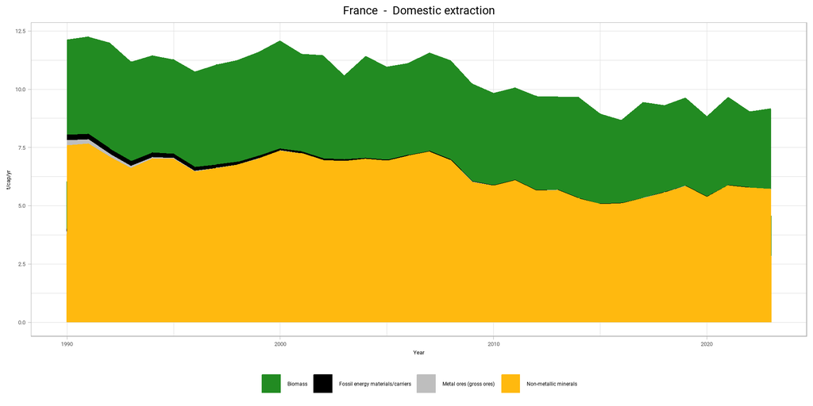

### DMI

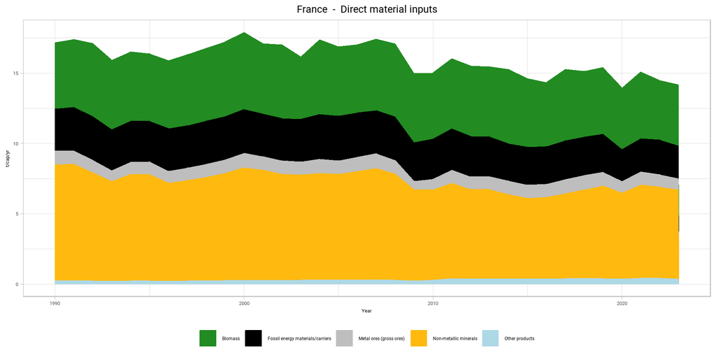

### DMC

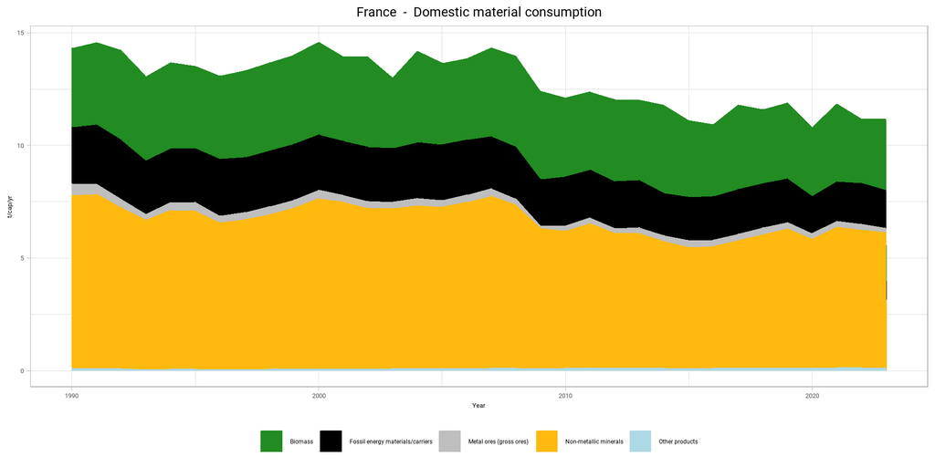

### Imports

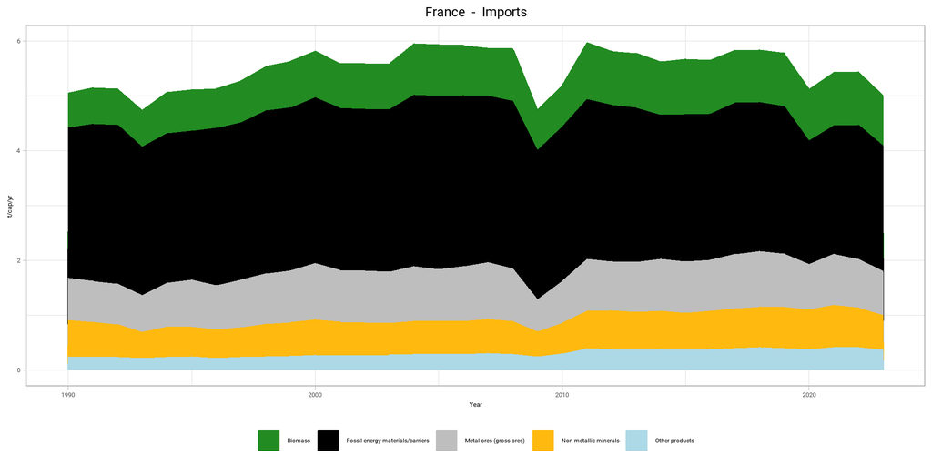

### Exports

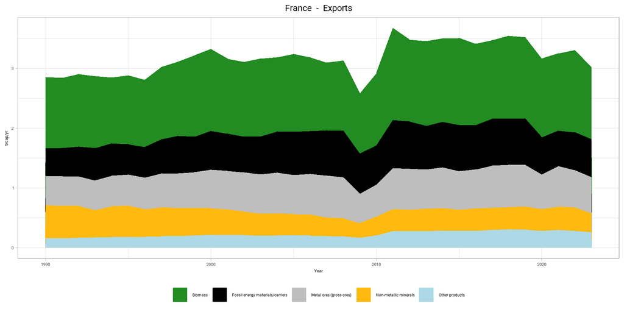

## E. Comparaison des profils pays dans le temps

### 1. Par indicateurs

1. Complétez la fonction de visualisation

```r
countries_to_compare = c('France', 'Spain', 'Germany', 'Estonia', 'Italy', 'Greece','Finland')

palette_countries = palette.colors(length(countries_to_compare))


comparison_visualiser = function(countries = countries_to_compare,
                                 indic_env_,
                                 unit_){
#' Comparison Visualiser Function
#'
#' Cette fonction génère un graphique ggplot qui compare l'évolution d'un indicateur du MFA
#' pour une sélection de pays. Les données sont filtrées par pays, indicateur environnemental,
#' unité de mesure et matériaux, puis agrégées par pays et par période.
#'
#' @param countries Vecteur de caractères. Liste des pays à comparer. Par défaut, la variable `countries_to_compare`.
#' @param indic_env_ Caractère. Indicateur environnemental à comparer (ex : "Domestic extraction", "Direct material inputs", etc.).
#' @param unit_ Caractère. Unité de mesure utilisée pour l'indicateur (ex : "Tonnes per capita").
#'
#' @return Un objet ggplot représentant l'évolution de l'indicateur pour chacun des pays sélectionnés.
#'
#' @examples
#' comparison_visualiser(countries = c('France', 'Germany'),
#'                       indic_env_ = "Domestic extraction",
#'                       unit_ = "Tonnes per capita")
  p = mfa_data_labeled %>%
    subset(geo %in% countries_to_compare) %>%   # Filtrer les données pour ne garder que les pays sélectionnés
    subset(indic_env == indic_env_) %>%           # Conserver uniquement l'indicateur environnemental spécifié
    subset(unit == unit_) %>%                     # Garder les données dans l'unité de mesure indiquée
    subset(material %in% summary_classes) %>%     # Filtrer pour ne conserver que les matériaux agrégés définis dans summary_classes
    group_by(geo, TIME_PERIOD) %>%                # Grouper par pays et par période
    mutate(overall = sum(values, na.rm = TRUE)) %>% # Calculer la somme des valeurs par groupe (agrégation)
    ungroup() %>%                                 # Dégroupement
    select(c('TIME_PERIOD', 'geo', 'overall')) %>%  # Sélectionner les variables d'intérêt
    ggplot(aes(x = TIME_PERIOD,                   # Définir l'axe des abscisses : la période (année)
               y = overall,                       # Définir l'axe des ordonnées : la valeur agrégée
               color = geo)) +                    # Colorer les lignes par pays
    geom_line(linewidth = 1) +                    # Ajouter une ligne pour représenter l'évolution
    scale_color_manual(values = unname(palette_countries)) +  # Définir manuellement les couleurs pour chaque pays
    custom_theme() +                              # Appliquer le thème personnalisé
    ylab(paste(indic_env_, "in", unit_)) +         # Ajouter une étiquette à l'axe des ordonnées indiquant l'indicateur et l'unité
    xlab(" ") +                                   # Laisser l'axe des abscisses sans titre
    labs(color = NULL)                            # Supprimer le titre de la légende pour les couleurs

  return(p)
}
```

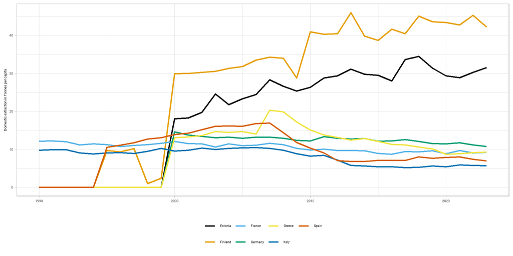

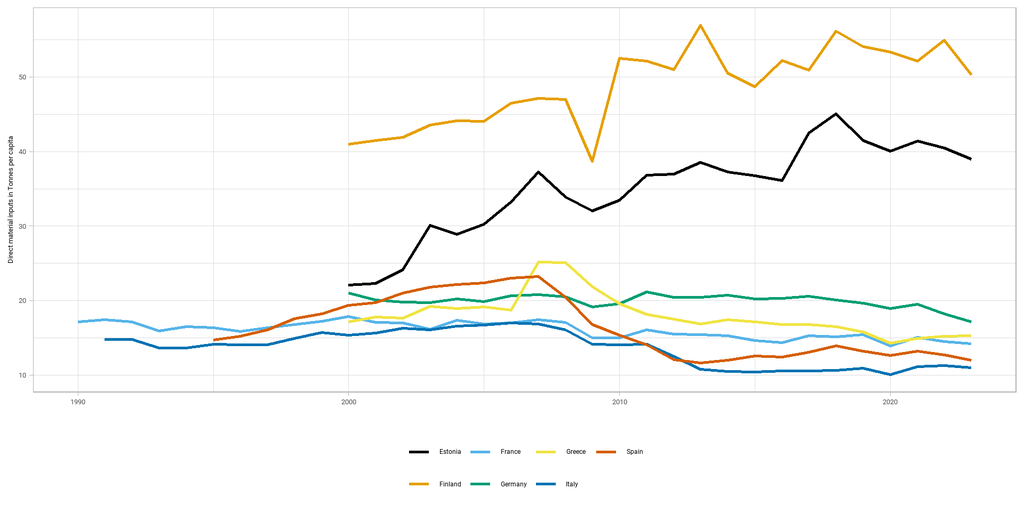

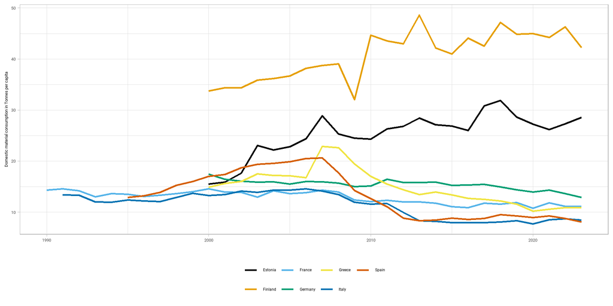

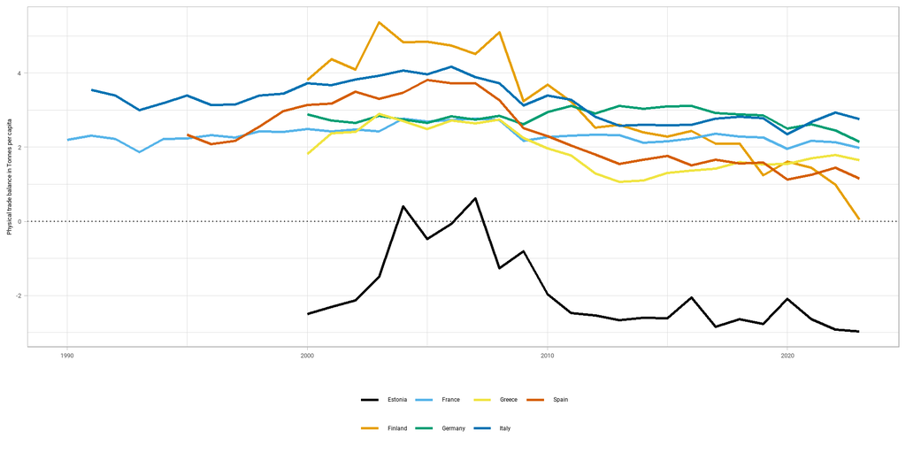

### 2. Productivité des ressources

$$\frac{PIB}{DMI}$$

1. Choisissez un échantillon de pays utile à comparer en Europe
2. Calculez leurs productivités des ressources
3. Montrez leur évolution dans le temps

```r
countries_to_compare = c('France', 'Spain', 'Germany', 'Estonia', 'Italy', 'Greece','Finland')
palette_countries = palette.colors(length(countries_to_compare))

# Filtrer et agréger les données pour obtenir le total des Direct Material Inputs (DMI)
# pour chaque pays et pour chaque période, en utilisant uniquement les matériaux
# inclus dans la liste summary_classes, exprimées en 'Thousand tonnes'.
```

```r
efficiency_data = mfa_data_labeled %>%
  # Conserver uniquement les pays spécifiés dans countries_to_compare
  subset(geo %in% countries_to_compare) %>%
  # Filtrer pour l'indicateur "Direct material inputs"
  subset(indic_env == "Direct material inputs") %>%
  # Filtrer pour garder uniquement les données dont l'unité est "Thousand tonnes"
  subset(unit == 'Thousand tonnes') %>%
  # Conserver uniquement les matériaux inclus dans summary_classes
  subset(material %in% summary_classes) %>%
  # Regrouper les données par pays et par période (année)
  group_by(geo, TIME_PERIOD) %>%
  # Calculer la somme des valeurs pour chaque groupe, ce qui donne le total des DMI
  mutate(overall = sum(values)) %>%
  # Dégroupement pour faciliter la manipulation ultérieure
  ungroup() %>%
  # Sélectionner uniquement les colonnes d'intérêt : année, pays et la valeur agrégée
  select(c('TIME_PERIOD', 'geo', 'overall'))
```

Rédigez le code pour visualiser les données

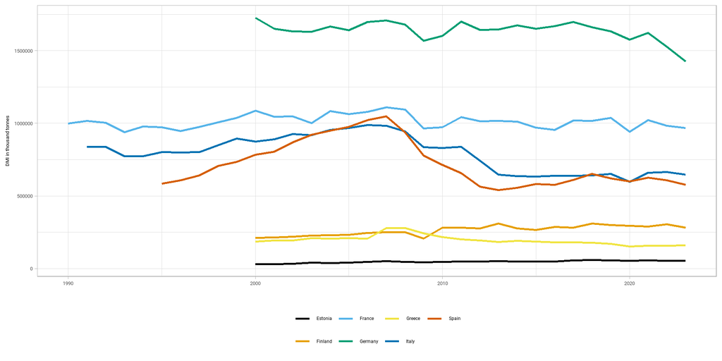

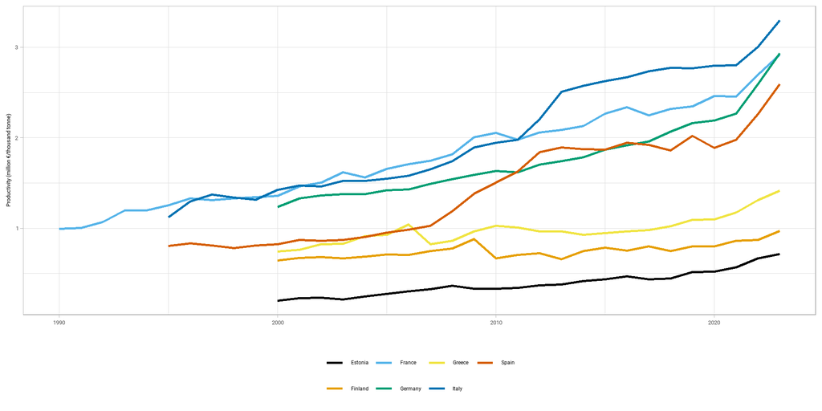

### 3. Efficacité matérielle

$$\frac{PIB}{DMC}$$

1. En utilisant les mêmes techniques, calculez l’efficacité matérielle
2. Quelle est la différence entre les deux mesures?
- Code
- Illustration

```r
performance = function(indic_env_, indicator, countries = countries_to_compare){
#' Performance Visualiser Function
#'
#' Cette fonction calcule et visualise une mesure de performance en joignant les données
#' de flux de matières (MFA) et les données de PIB. La performance est calculée en divisant
#' une variable économique (PIB) par une agrégation d'une variable MFA (par exemple, DMC ou DMI)
#' pour chaque pays et chaque période. Le résultat est visualisé sous forme de graphique linéaire.
#'
#' @param indic_env_ Caractère. L'indicateur MFA à utiliser (par exemple, "Domestic material consumption").
#' @param indicator Caractère. Le libellé de l'indicateur qui sera affiché sur l'axe des ordonnées (par exemple, "Efficiency (million €/thousand tonne)").
#' @param countries Vecteur de caractères. La liste des pays à analyser. Par défaut, utilise `countries_to_compare`.
#'
#' @return Un objet ggplot représentant l'évolution temporelle de la mesure de performance calculée pour chaque pays.
#'
#' @examples
#' performance("Domestic material consumption", "Efficiency (million €/thousand tonne)")

  # Filtrer les données MFA pour les pays sélectionnés, l'indicateur spécifié, l'unité "Thousand tonnes"
  # et pour les matériaux définis dans summary_classes.
  p = mfa_data_labeled %>%
    subset(geo %in% countries) %>%                      # Conserver uniquement les données des pays d'intérêt
    subset(indic_env == indic_env_) %>%                 # Filtrer selon l'indicateur MFA souhaité
    subset(unit == 'Thousand tonnes') %>%               # Garder uniquement les observations en "Thousand tonnes"
    subset(material %in% summary_classes) %>%           # Filtrer pour ne conserver que les matériaux agrégés
    group_by(geo, TIME_PERIOD) %>%                      # Grouper par pays et période pour agrégation
    mutate(overall = sum(values)) %>%                   # Calculer la somme des valeurs pour chaque groupe
    ungroup() %>%
    select(c('TIME_PERIOD', 'geo', 'overall')) %>%      # Sélectionner les colonnes d'intérêt

  # Fusionner les données agrégées avec les données de PIB sur les colonnes TIME_PERIOD et geo.
    full_join(gdp_data_labeled, by = c("TIME_PERIOD", "geo")) %>%
    subset(geo %in% countries_to_compare) %>%           # S'assurer que seuls les pays d'intérêt sont conservés
    drop_na() %>%                                       # Supprimer les observations comportant des valeurs manquantes
    mutate(new_var = values / overall) %>%              # Calculer la performance : PIB divisé par l'agrégation MFA
    ggplot(aes(x = TIME_PERIOD, y = new_var, color = geo)) +  # Construire le graphique avec ggplot2, en assignant TIME_PERIOD à l'axe x, la performance calculée à l'axe y et en colorant par pays
    geom_line(linewidth = 1) +                          # Tracer une ligne pour représenter l'évolution dans le temps
    scale_color_manual(values = unname(palette_countries)) +  # Attribuer manuellement les couleurs aux pays
    custom_theme() +                                    # Appliquer le thème personnalisé défini dans custom_theme()
    ylab(indicator) +                                   # Ajouter l'étiquette pour l'axe des ordonnées, correspondant au libellé de la mesure de performance
    xlab(" ") +                                       # Laisser l'axe des abscisses sans titre
    labs(color = NULL)                                # Supprimer le titre de la légende

  # Retourner le graphique ggplot généré
  return(p)
}
```

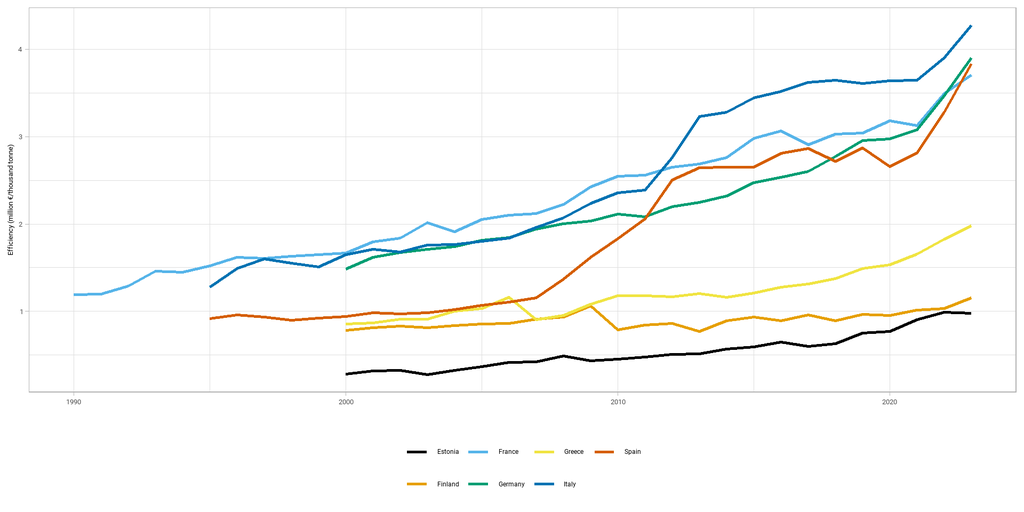

### Différence entre les deux mesures

Productivité matérielle(Resource Productivity ou RP):

- Quantité de valeur économique (PIB) générée par unité de matière entrante dans l’économie (DMI).
- capacité à créer de la valeur à partir des matières qui entrent dans le système économique.
- indicateur d’efficience économique orienté vers la production.

Efficacité matérielle (Material Efficiency ou ME):

- quantité de valeur économique (PIB) générée par unité de matière effectivement consommée par l’économie (DMC).
- focalise sur l’utilisation interne des matières pour créer de la valeur.
- exclut les matières qui sont simplement réexportées
- indicateur d’efficience écologique orienté vers la consommation.

peuvent diverger significativement pour les économies qui jouent un rôle important dans le commerce international de matières premières ou semi-transformées

### 4. Découplages matériaux ?

1. Calculez les taux de croissance des indicateurs : PIB et métaboliques
2. Tracez graphiquement leur évolutions

```r
growth_dmi = mfa_data_labeled %>%
  subset(geo %in% countries_to_compare) %>%            # Sélectionner uniquement les pays d'intérêt
  subset(indic_env == "Direct material inputs") %>%    # Garder uniquement les observations pour l'indicateur "Direct material inputs"
  subset(unit == 'Thousand tonnes') %>%                # Filtrer pour conserver les données en "Thousand tonnes"
  subset(material %in% summary_classes) %>%            # Ne conserver que les matériaux appartenant aux classes agrégées (summary_classes)
  group_by(geo, TIME_PERIOD) %>%                       # Grouper les données par pays et par période (année)
  mutate(overall = sum(values)) %>%                    # Calculer la somme des valeurs pour chaque groupe (total DMI par pays et par année)
  ungroup() %>%                                       # Dégroupement pour les opérations ultérieures
  select(indic_env, geo, TIME_PERIOD, overall) %>%     # Sélectionner les colonnes pertinentes pour l'analyse
  group_by(geo) %>%                                   # Regrouper à nouveau par pays pour calculer la croissance dans le temps
  arrange(TIME_PERIOD) %>%                            # Ordonner les données chronologiquement pour chaque pays
  mutate(DMI = (overall / lag(overall) - 1) * 100) %>% # Calculer le taux de croissance en pourcentage : ((valeur actuelle / valeur précédente) - 1) * 100
  ungroup() %>%                                       # Dégroupement final
  distinct() %>%                                      # Retirer les doublons éventuels
  subset(DMI != 0)                                    # Filtrer pour supprimer les observations où le taux de croissance est nul
```

Ecrivez le code pour calculer le taux de variation du PIB :

```r
growth_gdp = gdp_data_labeled%>%
  subset(geo %in% countries_to_compare)%>%            # Pays que l'on souhaite conserver
  group_by(geo) %>%                                   # Grouping by geo (or another grouping variable)
  arrange(TIME_PERIOD) %>%                            # Ensure the data is in time order
  mutate(GDP = (values / lag(values) - 1) * 100) %>% # Compute growth rate in percent
  ungroup()%>%
  distinct()
```

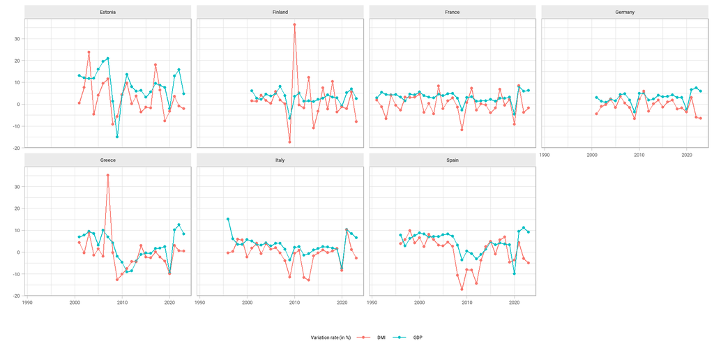

### 5. Evolutions des demandes de matériaux liés à la transition

Lisez l’article de [O. Vidal et al. , *Nature Geosciences*, 2013](https://www.researchgate.net/publication/258514690_Metals_for_a_low-carbon_society)

- Cuivre :
  - Essentiel pour les infrastructures électriques (câblage, moteurs, transformateurs) et les réseaux intelligents.
  - Forte demande mondiale due à l’électrification et aux énergies renouvelables, entraînant des risques de tensions d’approvisionnement.
  - La concentration géographique de certaines réserves peut accentuer la vulnérabilité aux perturbations géopolitiques.
- Nickel :
  - Batteries lithium-ion, cruciales pour le stockage d’énergie et les véhicules électriques.
- Or, argent, platine et métaux précieux :
  - Electronique de pointe
  - Rareté et la concentration des mines dans certains pays posent des risques d’approvisionnement et de volatilité des prix.
- Bauxite et autre Aluminium :
  - Transformation de la bauxite en aluminium
  - Légèreté et résistance: matériau de choix pour l’automobile, l’aéronautique et les infrastructures renouvelables.
- Uranium Thorium
  - Sources de combustible pour la production d’énergie nucléaire, offrant une solution bas carbone pour la transition énergétique.
  - Disponibilité de thorium pourrait offrir des alternatives: nécessite encore des développements technologiques et réglementaires.
- Autres métaux non ferreux :
  - Divers éléments critiques utilisés dans la fabrication de composants électroniques, batteries, et technologies renouvelables.

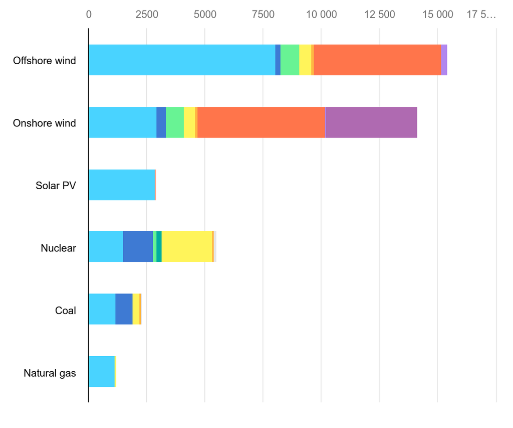

[Rapport de l’IEA, 2020](https://www.iea.org/reports/the-role-of-critical-minerals-in-clean-energy-transitions)

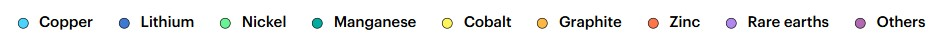

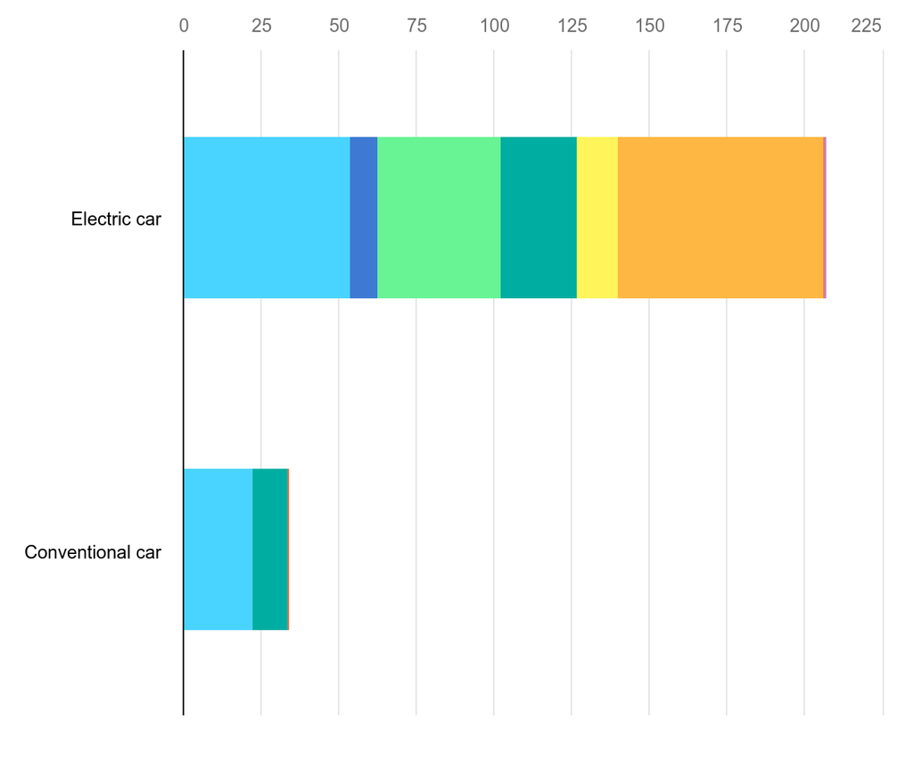

[Rapport de l’IEA, 2020](https://www.iea.org/reports/the-role-of-critical-minerals-in-clean-energy-transitions)

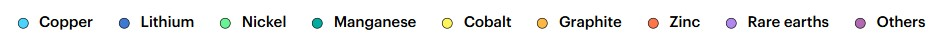

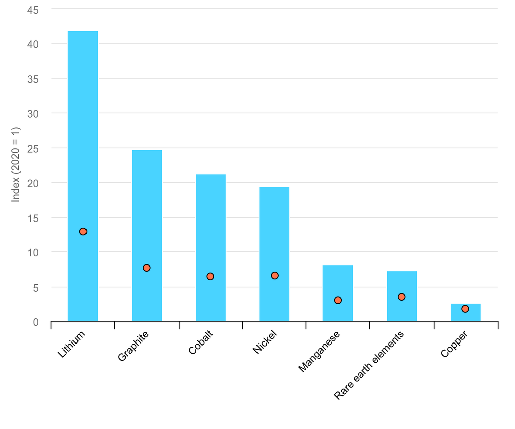

[Rapport de l’IEA, 2020](https://www.iea.org/reports/the-role-of-critical-minerals-in-clean-energy-transitions)

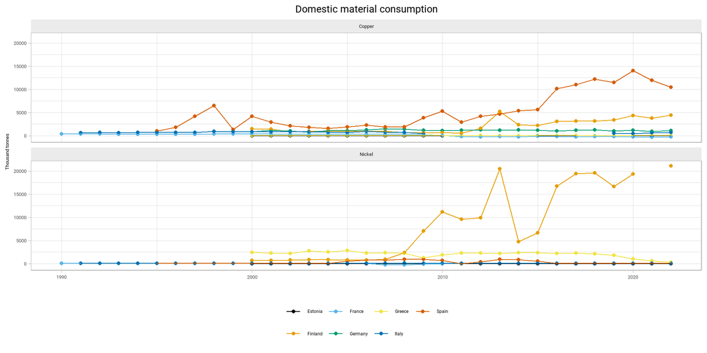

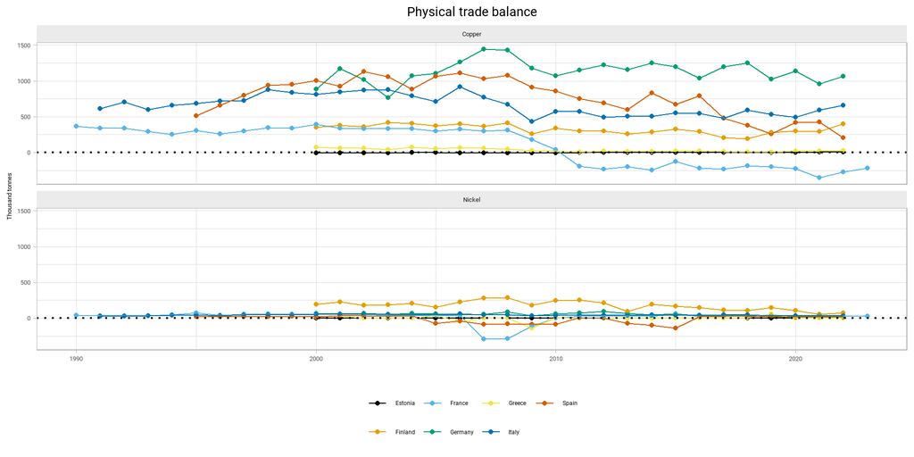